# SAI-assignment-5

Daniel Verdejo 22240224

2022-12-10

Amount Net dollar amount spent by customers in their latest purchase from this retailer;

- *Recency* Number of months since the last purchase;
- *Freq12* Number of purchases in the last 12 months;
- *Dollar12* Dollar amount of purchases in the last 12 months;
- *Freq24* Number of purchases in the last 24 months;
- *Dollar24* Dollar amount of purchases in the last 24 months;
- *Card* 1 for customers who have a private-label credit card with the retailer, 0 if not,

where the *Amount* of money spent by a customer is the response variable, while the rest of variables are explanatory variables.

```
##   Amount Recency Freq12 Dollar12 Freq24 Dollar24 Card
## 1      0      22      0        0      3      400    0
## 2      0      30      0        0      0        0    0
## 3      0      24      0        0      1      250    0
## 4     30       6      3      140      4      225    0
## 5     33      12      1       50      1       50    0
## 6     35      48      0        0      0        0    0
```

```
## [1] "Amount"   "Recency"  "Freq12"   "Dollar12" "Freq24"   "Dollar24" "Card"
```

```
##      Amount           Recency           Freq12          Dollar12
##  Min.   :      0   Min.   : 1.000   Min.   : 0.000   Min.   :   0.0
##  1st Qu.:     50   1st Qu.: 3.000   1st Qu.: 1.000   1st Qu.: 107.5
##  Median :     70   Median : 4.500   Median : 3.000   Median : 223.5
##  Mean   :  25201   Mean   : 7.217   Mean   : 2.883   Mean   : 372.0
##  3rd Qu.:    100   3rd Qu.: 8.000   3rd Qu.: 4.000   3rd Qu.: 406.5
##  Max.   :1506000   Max.   :48.000   Max.   :10.000   Max.   :5000.0
##      Freq24          Dollar24           Card
##  Min.   : 0.000   Min.   :   0.0   Min.   :0.0000
##  1st Qu.: 4.000   1st Qu.: 260.2   1st Qu.:0.0000
##  Median : 6.000   Median : 461.5   Median :0.0000
##  Mean   : 5.617   Mean   : 660.8   Mean   :0.3333
##  3rd Qu.: 7.250   3rd Qu.: 718.5   3rd Qu.:1.0000
##  Max.   :13.000   Max.   :8000.0   Max.   :1.0000
```

Lets first visualise the correlation and relationship between the explanatory variables and the target variable:

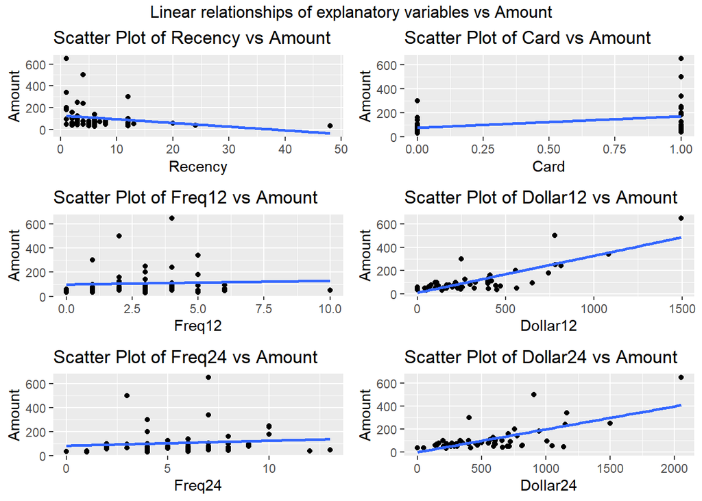

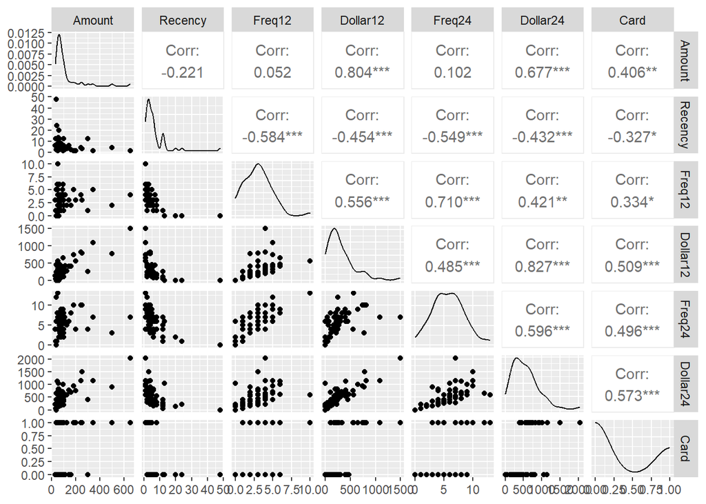

```
##               Amount    Recency      Freq12   Dollar12     Freq24   Dollar24
## Amount    1.00000000 -0.2208139  0.05159862  0.8036804  0.1017170  0.6773219
## Recency  -0.22081392  1.0000000 -0.58382258 -0.4538679 -0.5490906 -0.4323811
## Freq12    0.05159862 -0.5838226  1.00000000  0.5558579  0.7099506  0.4214650
## Dollar12  0.80368037 -0.4538679  0.55585788  1.0000000  0.4849486  0.8274500
## Freq24    0.10171701 -0.5490906  0.70995061  0.4849486  1.0000000  0.5962226
## Dollar24  0.67732192 -0.4323811  0.42146503  0.8274500  0.5962226  1.0000000
## Card      0.40556686 -0.3274373  0.33369756  0.5087929  0.4955987  0.5730935
##                Card
## Amount    0.4055669
## Recency  -0.3274373
## Freq12    0.3336976
## Dollar12  0.5087929
## Freq24    0.4955987
## Dollar24  0.5730935
## Card      1.0000000
```

As we can see from the scatter plot of explanatory variables vs the target variable Amount there are linear relationships between the explanatory variables and the target variable.

Recency has a negative linear relation ship while the rest of the explanatory variables have positive linear relationships with the target variable in varying degrees. The Dollar12 and Dollar24 Have highly positive relationships while Amount vs Card, Freq12, and Freq24 all have weak relationships: In this case, the line suggests that the explanatory variables have little to no effect on the target variable. This is backed up by the weak correlation values we see between the Freq12 / Freq24 variables and Amount. But, they appear to have strong correlation to Dollar12 / Dollar24, and as such we should explore their relationships.

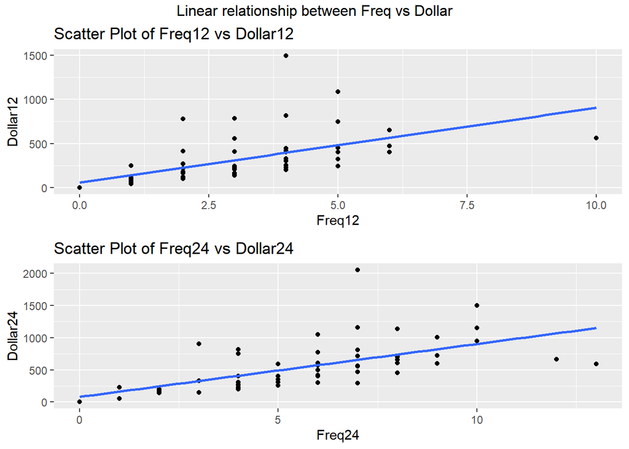

As we can see, there is a linear relationship between the Freq12 and Dollar12 explanatory variables, as well as Freq24 and Dollar24 explanatory variables. This is backed up by their moderate correlations with each other: - Freq12 and Dollar12: 0.556 - Freq24 and Dollar24: 0.596

We should first see what we can find out when we apply all explanatory variables against the multiple linear regresssion model (MLR), and find out where improvements can be made.

```r
model <- lm(Amount ~ Recency + Freq12 + Dollar12 + Freq24 + Dollar24 + Card, data = data)

summary(model)
```

```
##
## Call:
## lm(formula = Amount ~ Recency + Freq12 + Dollar12 + Freq24 +
##     Dollar24 + Card, data = data)
##
## Residuals:
##     Min      1Q  Median      3Q     Max
## -63.799 -12.218  -3.334   7.299 156.822
##
## Coefficients:
##               Estimate Std. Error t value Pr(>|t|)
## (Intercept) 104.251935  19.834341   5.256 3.20e-06 ***
## Recency      -1.345963   0.971053  -1.386    0.172
## Freq12      -32.353539   5.187870  -6.236 1.01e-07 ***
## Dollar12      0.429683   0.041325  10.398 5.43e-14 ***
## Freq24       -5.173593   3.619661  -1.429    0.159
## Dollar24      0.001756   0.031850   0.055    0.956
## Card         14.624409  14.575770   1.003    0.321
## ---
## Signif. codes:  0 '***' 0.001 '**' 0.01 '*' 0.05 '.' 0.1 ' ' 1
##
## Residual standard error: 40.83 on 49 degrees of freedom
## Multiple R-squared:  0.882,  Adjusted R-squared:  0.8675
## F-statistic: 61.02 on 6 and 49 DF,  p-value: < 2.2e-16
```

```r
regression_table <- get_regression_table(model = model)

regression_table
```

```
## # A tibble: 7 × 7
##   term      estimate std_error statistic p_value lower_ci upper_ci
##   <chr>        <dbl>     <dbl>     <dbl>   <dbl>    <dbl>    <dbl>
## 1 intercept  104.       19.8       5.26    0       64.4    144.
## 2 Recency     -1.35      0.971    -1.39    0.172   -3.30     0.605
## 3 Freq12     -32.4       5.19     -6.24    0      -42.8    -21.9
## 4 Dollar12     0.43      0.041    10.4     0        0.347    0.513
## 5 Freq24      -5.17      3.62     -1.43    0.159  -12.4      2.1
## 6 Dollar24     0.002     0.032     0.055   0.956   -0.062    0.066
## 7 Card        14.6      14.6       1.00    0.321  -14.7     43.9
```

## Observations

- Freq12 and Freq24 have extremely different coefficients, which given their strong positive association of 0.710 we may have expected them to be similar.
- Dollar12 and Dollar24 also have very differing coefficients, again given their strong positive association of 0.827 we also would have expected them to be similar.
- We can see that Dollar24, and Card have quite large p values despite them having moderate correlation values to the target variable this is somewhat contradictory of what we would expect.
- Furthermore, if we inspect the confidence intervals for these two in particular, we see that they both include zero.

If we look at the F-statistic we find that we have a large value for the F test statistic of 61.02 and a p value of 2.2e-16 which is lower than the 0.05 cutoff so its considered significant and we can reject the null hypothesis. All this is evidence to the explanatory variables and model being useful for explaining variation, so there is a contradiction from what discovered before.

The reason we are seeing these contradictions is multicollinearity. Multicollinearity is where two explanatory variables are measuring the same underlying concept or linearly related. Its Generally good practice to exclude one of the two explanatory variables that have a strong correlation between each other from the model to improve the accuracy of our predictions but more importantly reduce or eradicate the contradictions we have just discovered. first we will experiment and see what the 3 different scenarios produce (i.e how accurate is our prediction?).

```r
row12 <- data[12, ]
print(row12)
```

```
##    Amount Recency Freq12 Dollar12 Freq24 Dollar24 Card
## 12     50       1     10      562     13      595    1
```

lets do some predictions from our fitted model for row number 12 from our dataset: The actual value is 50, the predicted amount if we calculate using the estimate from above:

```r
paste("Predicted value: ", regression_table$estimate[1] + prod(regression_table$estimate[2:7]),
    "  vs Actual value: ", row12$Amount)
```

```
## [1] "Predicted value:  101.41823328352   vs Actual value:  50"
```

As we can see the prediction is way off, lets try again without Freq24 and Dollar24

```r
model12 <- lm(Amount ~ Recency +
              Freq12 +
              Dollar12 +
              Freq12 * Dollar12 +
              Card, data = data)

summary(model12)
```

```
##
## Call:
## lm(formula = Amount ~ Recency + Freq12 + Dollar12 + Freq12 *
##     Dollar12 + Card, data = data)
##
## Residuals:
##     Min      1Q  Median      3Q     Max
## -79.726 -13.604  -2.943   7.286 149.033
##
## Coefficients:
##                  Estimate Std. Error t value Pr(>|t|)
## (Intercept)      61.91260   25.40289   2.437 0.018401 *
## Recency          -0.28582    1.10940  -0.258 0.797747
## Freq12          -28.85803    6.95210  -4.151 0.000129 ***
## Dollar12          0.50587    0.06012   8.415 3.83e-11 ***
## Card              7.75326   13.49576   0.574 0.568208
## Freq12:Dollar12  -0.02050    0.01525  -1.345 0.184825
## ---
## Signif. codes:  0 '***' 0.001 '**' 0.01 '*' 0.05 '.' 0.1 ' ' 1
##
## Residual standard error: 40.75 on 50 degrees of freedom
## Multiple R-squared:   0.88,  Adjusted R-squared:  0.868
## F-statistic: 73.36 on 5 and 50 DF,  p-value: < 2.2e-16
```

```r
regTable12 <- get_regression_table(model = model12)
```

No real change in our R-squared error

```r
print(regTable12)
```

```
## # A tibble: 6 × 7
##   term            estimate std_error statistic p_value lower_ci upper_ci
##   <chr>              <dbl>     <dbl>     <dbl>   <dbl>    <dbl>    <dbl>
## 1 intercept         61.9      25.4       2.44    0.018   10.9    113.
## 2 Recency           -0.286     1.11     -0.258   0.798   -2.51     1.94
## 3 Freq12           -28.9       6.95     -4.15    0      -42.8    -14.9
## 4 Dollar12           0.506     0.06      8.41    0        0.385    0.627
## 5 Card               7.75     13.5       0.574   0.568  -19.4     34.9
## 6 Freq12:Dollar12   -0.021     0.015    -1.34    0.185   -0.051    0.01
```

```r
paste("Predicted value: ", regTable12$estimate[1] + prod(regTable12$estimate[2:6]),
    "  vs Actual value: ", row12$Amount)
```

```
## [1] "Predicted value:  61.2330580166153   vs Actual value:  50"
```

Much closer! Lets check the 24 features and see how that compares

```r
model24 <- lm(Amount ~ Recency +
              Freq24 +
              Dollar24 +
              Freq24 * Dollar24 +
              Card, data = data)

summary(model24)
```

```
##
## Call:
## lm(formula = Amount ~ Recency + Freq24 + Dollar24 + Freq24 *
##     Dollar24 + Card, data = data)
##
## Residuals:
##      Min       1Q   Median       3Q      Max
## -190.806  -22.479    2.561   19.561  208.342
##
## Coefficients:
##                   Estimate Std. Error t value Pr(>|t|)
## (Intercept)      69.427386  56.396747   1.231  0.22406
## Recency          -1.018578   1.859621  -0.548  0.58631
## Freq24          -19.110502   8.568164  -2.230  0.03024 *
## Dollar24          0.299225   0.092894   3.221  0.00225 **
## Card             32.659558  25.686004   1.271  0.20944
## Freq24:Dollar24  -0.005669   0.012710  -0.446  0.65749
## ---
## Signif. codes:  0 '***' 0.001 '**' 0.01 '*' 0.05 '.' 0.1 ' ' 1
##
## Residual standard error: 72.5 on 50 degrees of freedom
## Multiple R-squared:  0.6204, Adjusted R-squared:  0.5824
## F-statistic: 16.34 on 5 and 50 DF,  p-value: 1.561e-09
```

```r
regTable12 <- get_regression_table(model = model24)
```

Based solely off the R-squared values, we can assume that this model will perform worse than the last model but lets make a prediction anyway.

```r
print(regTable12)
```

```
## # A tibble: 6 × 7
##   term            estimate std_error statistic p_value lower_ci upper_ci
##   <chr>              <dbl>     <dbl>     <dbl>   <dbl>    <dbl>    <dbl>
## 1 intercept         69.4      56.4       1.23    0.224  -43.8    183.
## 2 Recency           -1.02      1.86     -0.548   0.586   -4.75     2.72
## 3 Freq24           -19.1       8.57     -2.23    0.03   -36.3     -1.90
## 4 Dollar24           0.299     0.093     3.22    0.002    0.113    0.486
## 5 Card              32.7      25.7       1.27    0.209  -18.9     84.3
## 6 Freq24:Dollar24   -0.006     0.013    -0.446   0.657   -0.031    0.02
```

```r
paste("Predicted value: ", regTable12$estimate[1] + prod(regTable12$estimate[2:6]),
    "  vs Actual value: ", row12$Amount)
```

```
## [1] "Predicted value:  68.2859722265077   vs Actual value:  50"
```

Looks like its slightly worse, so we’ll go with the Freq12 and Dollar12

```r
#set the seed and then run the bootstrap samples
set.seed(22240224)
modelFn <- function(data, i) {
  m <- lm(Amount ~ Freq12 +
            Dollar12 +
            Freq12 * Dollar12 +
            Card, data = data[i, ])

  return(coef(m))
}

results <- boot(data, modelFn, R = 10000)

results
```

```
##
## ORDINARY NONPARAMETRIC BOOTSTRAP
##
##
## Call:
## boot(data = data, statistic = modelFn, R = 10000)
##
##
## Bootstrap Statistics :
##         original       bias    std. error
## t1*  56.51758985 -0.079598991 11.11779494
## t2* -27.71103941  0.551596246  4.48545672
## t3*   0.51385290  0.016612582  0.11458607
## t4*   8.17801165 -1.420797121 11.21121501
## t5*  -0.02252985 -0.006427376  0.02416982
```

```r
conf_intervals <- boot.ci(boot.out = results, type =  c("norm", "basic", "perc", "bca"))

conf_intervals
```

```
## BOOTSTRAP CONFIDENCE INTERVAL CALCULATIONS
## Based on 10000 bootstrap replicates
##
## CALL :
## boot.ci(boot.out = results, type = c("norm", "basic", "perc",
##     "bca"))
##
## Intervals :
## Level      Normal              Basic
## 95%   (34.81, 78.39 )   (31.67, 75.46 )
##
## Level     Percentile            BCa
## 95%   (37.57, 81.37 )   (38.87, 83.25 )
## Calculations and Intervals on Original Scale
```

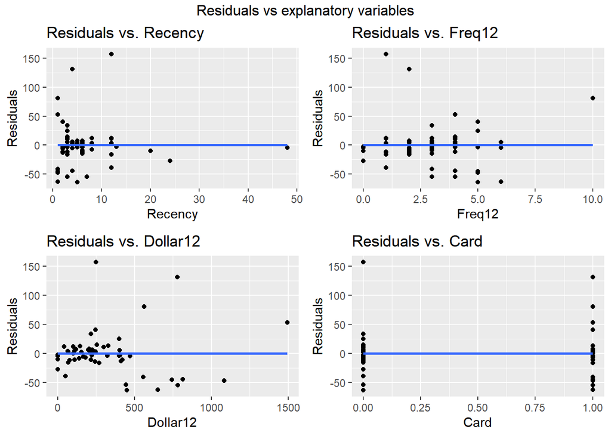

```r
residuals <- residuals(model)

# Combine the residuals with the data
residuals_df <- cbind(data, residuals)

rp1 <- ggplot(residuals_df, aes(x = Recency, y = residuals)) +
  geom_point() +
  geom_smooth(method = "lm", se = FALSE) +
  xlab("Recency") +
  ylab("Residuals") +
  ggtitle("Residuals vs. Recency")
rp2 <- ggplot(residuals_df, aes(x = Freq12, y = residuals)) +
  geom_point() +
  geom_smooth(method = "lm", se = FALSE) +
  xlab("Freq12") +
  ylab("Residuals") +
  ggtitle("Residuals vs. Freq12")
rp3 <- ggplot(residuals_df, aes(x = Dollar12, y = residuals)) +
  geom_point() +
  geom_smooth(method = "lm", se = FALSE) +
  xlab("Dollar12") +
  ylab("Residuals") +
  ggtitle("Residuals vs. Dollar12")
rp4 <- ggplot(residuals_df, aes(x = Card, y = residuals)) +
  geom_point() +
  geom_smooth(method = "lm", se = FALSE) +
  xlab("Card") +
  ylab("Residuals") +
  ggtitle("Residuals vs. Card")

grid.arrange(grobs= list(rp1,rp2,rp3,rp4), ncols=2, top="Residuals vs explanatory variables" )
```

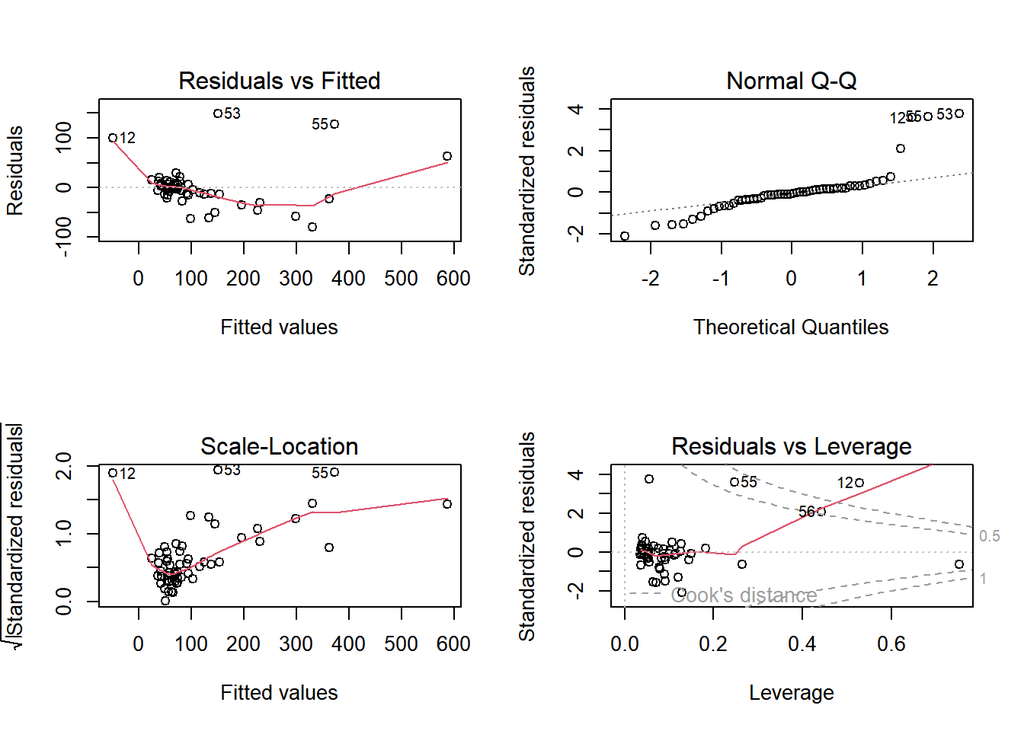

```r
par(mfrow = c(2, 2))  # Set the layout of the plot to be 2x2
plot(model12)
```

1. Using a subset selection procedure on the variables above, construct a model that best predict the Amount of money spent by a customer. Summarise the key features of the model fit and performance, and check the underlying assumptions.

When evaluating the fit and performance of a statistical model, there are several key features that you should summarize and assess. These include: 1. The model’s overall fit to the data, which can be assessed using measures such as the R-squared value, the adjusted R-squared value, and the residual standard error. 2. The statistical significance of the model’s coefficients, which can be assessed using hypothesis tests or confidence intervals. 3. The individual effects of the predictor variables on the response variable, which can be assessed using measures such as t-tests, p-values, and confidence intervals. 4. The model’s predictive accuracy, which can be assessed using measures such as the mean squared error (MSE), the root mean squared error (RMSE), and the mean absolute error (MAE).

Additionally, when building and evaluating a statistical model, it is important to check the underlying assumptions of the model. These assumptions include:

1. Linearity: The relationship between the predictor and response variables is linear.
2. Normality: The residuals are normally distributed.
3. Independence: The observations are independent of each other.
4. Equal variances: The variances of the residuals are equal for all values of the predictor variable.
5. Outlier detection: The data does not contain any extreme values or outliers.

By summarizing the key features of the model fit and performance, and checking the underlying assumptions, you can gain a better understanding of the model’s strengths and weaknesses, and make informed decisions about how to improve it.

Assumptions Underlying the Model: LINE 1.Population relationship between the mean response and the features is linear (Linearity assumption); 2.Sample is representative of the population and the subjects are independent (Independence assumption); 3.Errors follow a normal distribution, centred about the regression line (Normality assumption); 4.Variance of the errors is the same for any value of the explanatory variable (Equal Spreads assumption).